[OHI-Northeast](http://www.ohi-northeast.org/) | [OHI Science](http://ohi-science.org) | [Citation policy](http://ohi-science.org/citation-policy/)

# OHI-Northeast: Economic access data layer

Compiled on Mon Nov 25 10:20:56 2019 by afflerbach

```r
knitr::opts_chunk$set(fig.width = 6, fig.height = 4, fig.path = 'figs/',
                      message = FALSE, warning = FALSE)

source('~/github/ne-prep/src/R/common.R')  ### an OHINE specific version of common.R

dir_git <- '~/github/ne-prep'
dir_anx <- file.path(dir_M, 'git-annex/neprep')

#libraries
library(tidyverse)
```

# Summary

# Data Source

### BLS wage data

**Downloaded**: Downloaded using blscrapeR R package each time this code is run

**Description**: Wage data

**Native data resolution**: County level

**Time range**: 2001-2017

**Format**: Tabular

**Reference**: [Bureau of Labor Statistics](https://www.bls.gov/bls/blswage.htm)

### Gasoline prices by county

**Downloaded**: July 23, 2019

**Description**: Gas price data

**Native data resolution**: County level

**Format**: Tabular

**Reference**: [US Energy Information Administration](https://www.eia.gov/petroleum/gasdiesel/)

**Download Link:** https://www.eia.gov/state/seds/seds-data-complete.php?sid=US#PricesExpenditures

# Analysis

I’m using the `blscrapeR` package and have my own API access key. We aren’t using the NOEP data because we don’t want to limit this to only jobs that are tied to the ocean economy.

```r
#devtools::install_github("keberwein/blscrapeR")
library(blscrapeR)
#read in API access key that is saved on Mazu
blsKey <- striprtf::read_rtf(file.path(dir_M,'git-annex/neprep/keys/BureauofLaborStatistics.rtf'))
#set_bls_key(blsKey, overwrite=TRUE)
```

Grab several data sets from the BLS at once.

> NOTE on series IDs: - Connecticut – Statewide Average Annual Pay All establishment sizes Total Covered Total, all industries: ENU0900050010 - Maine – Statewide Average Annual Pay All establishment sizes Total Covered Total, all industries: ENU2300050010 - Massachusetts – Statewide Average Annual Pay All establishment sizes Total Covered Total, all industries: ENU2500050010 - New Hampshire – Statewide Average Annual Pay All establishment sizes Total Covered Total, all industries: ENU3300050010 - New York – Statewide Average Annual Pay All establishment sizes Total Covered Total, all industries: ENU3600050010 - Rhode Island – Statewide Average Annual Pay All establishment sizes Total Covered Total, all industries: ENU4400050010

```r
bls_data <- bls_api(c("ENU0900050010", "ENU2300050010", "ENU2500050010", "ENU3300050010", "ENU3600050010", "ENU4400050010"),
              startyear = 2001, endyear = 2017, Sys.getenv("BLS_KEY"))

avg_pay_by_state <- bls_data %>%
  mutate(state = case_when(
    seriesID == "ENU0900050010" ~ "CT",
    seriesID == "ENU2300050010" ~ "ME",
    seriesID == "ENU2500050010" ~ "MA",
    seriesID == "ENU3300050010" ~ "NH",
    seriesID == "ENU3600050010" ~ "NY",
    seriesID == "ENU4400050010" ~ "RI"
  )) %>%
  select(year, pay = value, state)
```

Average across states to get average pay across the Northeast. This is not weighted by population or number of jobs or anything. The BLS data does not allow easy aggregation to the Northeast area so we are simply taking an average across all states.

```r
avg_pay_ne <- avg_pay_by_state %>%
  group_by(year) %>%
  summarize(pay = mean(pay)) %>%
  mutate(state = "Northeast") %>%
  ungroup()
```

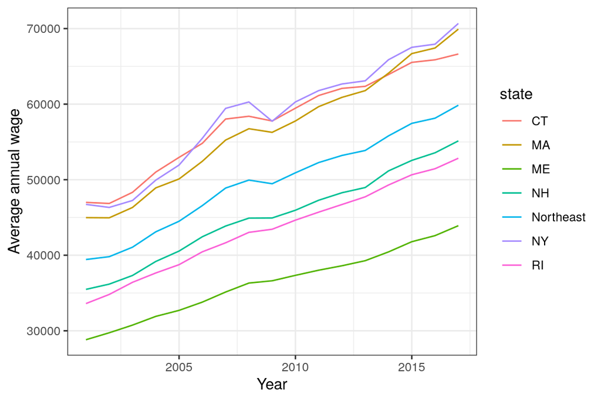

```r
avg_pay <- bind_rows(avg_pay_by_state, avg_pay_ne)

ggplot(avg_pay, aes(x = year, y = pay, color = state)) +
  geom_line() +
  labs(x = "Year",
       y = "Average annual wage") +
  theme_bw()
```

## Gas price data

The gas price data is loaded but it is provided in $/MMBtu (Millions of British thermal units), which can be converted to approximate dollars per gallon using the heat contents provided by the EIA here. Once multiplied we get dollars per barrel, and then divide by 42 since there are 42 U.S. gallons in a barrel.

```r
raw        <- read_csv(file.path(dir_anx, "_raw_data/EIA/pr_all.csv"))
conversion <- read_csv(file.path(dir_anx, "_raw_data/EIA/MER_TA3.csv")) %>% #data to convert raw data from Btu to barrels
  filter(Description == "Motor Gasoline (Finished) Consumption Heat Content") %>%
  mutate(Year = str_sub(YYYYMM, 1, str_length(YYYYMM)-2),
         conv_factor = as.numeric(Value)) %>%
  select(Year, conv_factor)
```

Clean data and multiply by Btu conversion to get dollars per gallon.

```r
clean_gas_data_states <- raw %>%
  filter(State %in% c("NY", "CT", "RI", "MA", "NH", "ME"), #filter for just our states
         MSN == "MGACD") %>% #this is the code for gasoline prices for the transportation sector
  gather(key = "Year", value = "dollar_per_MMBtu", -Data_Status, -State, -MSN) %>%
  left_join(conversion) %>%
  mutate(Year = as.numeric(Year),
    dollar_per_gallon = dollar_per_MMBtu*conv_factor/42) %>% #multiply $/btu by conversion to get $/barrel, then divide by 42 to get dollar per gallon since there are 42 gallons in a barrel
  select(-Data_Status, -MSN, -conv_factor, -dollar_per_MMBtu)
```

Take the average across states to get the Northeast average

```r
clean_gas_data_ne <- clean_gas_data_states %>%
  group_by(Year) %>%
  summarize(dollar_per_gallon = mean(dollar_per_gallon)) %>%
  mutate(State = "Northeast")
```

Combine states and region-wide

```r
clean_gas_data <- bind_rows(clean_gas_data_ne, clean_gas_data_states)
```

Cost of gas in US Dollars per Gallon for Northeast states.

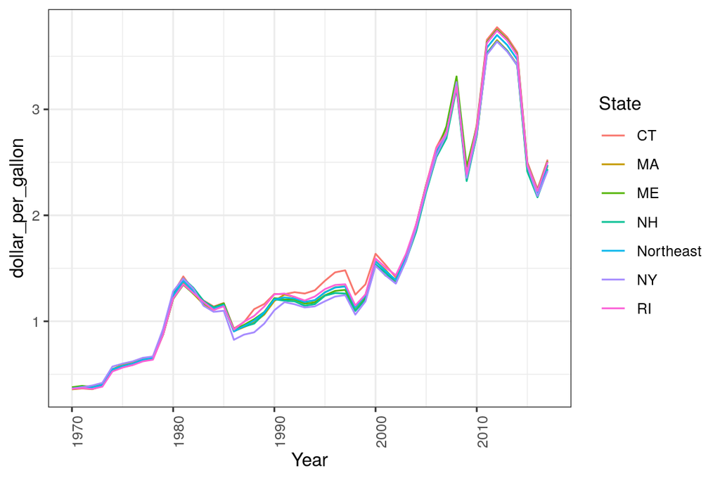

```r
ggplot(clean_gas_data, aes(x = Year, y = dollar_per_gallon, color = State, group = State)) +
  geom_line() +
  theme_bw() +
  theme(axis.text.x = element_text(angle = 90))
```

## Get ratio

Compare wage to gas price each year.

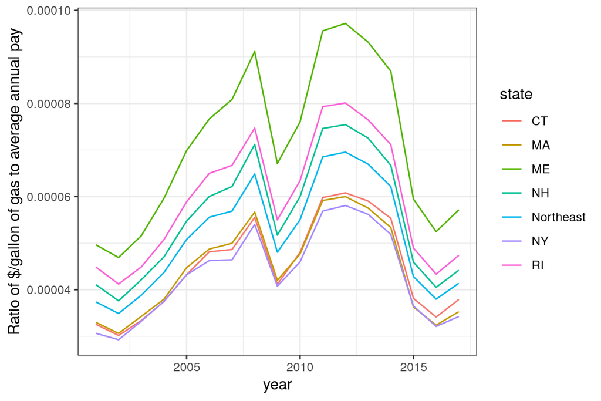

```r
gas_to_income <- clean_gas_data %>%
  select(year = Year, state = State, dollar_per_gallon) %>%
  left_join(avg_pay) %>%
  filter(!is.na(pay)) %>%
  mutate(ratio = dollar_per_gallon/pay)

write_csv(gas_to_income, "data/gas_to_income_ratio.csv")

ggplot(gas_to_income, aes(x = year, y = ratio, color = state)) +
  geom_line() +
  theme_bw() +
  labs(y = "Ratio of $/gallon of gas to average annual pay")
```

## Calculate year over year change and score

```r
change <- gas_to_income %>%
  arrange(year) %>%
  group_by(state) %>%
  mutate(last_years_ratio = lag(ratio, n = 1)) %>%
  ungroup() %>%
  mutate(change = ratio-last_years_ratio,
         score  = ifelse(change < 0, 1, 1-(change/last_years_ratio)))
```

# Results

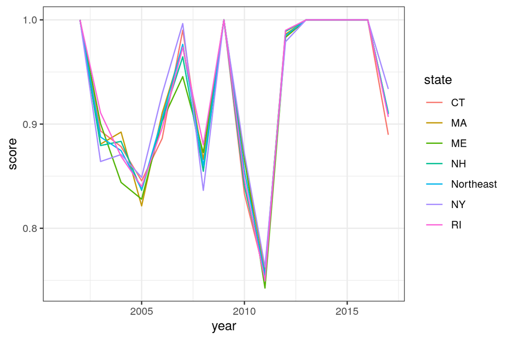

```r
ggplot(change, aes(x = year, y = score, color = state)) +
  geom_line() +
  theme_bw()
```

# Save to toolbox

Saving data to the toolbox and to the data folder

```r
write_csv(avg_pay, "data/avg_pay_by_state.csv")
```

```r
clean_gas_data %>%
  left_join(rgn_data, by = c("State" = "state_abv")) %>%
  mutate(rgn_id = ifelse(State == "Northeast", 12, rgn_id)) %>%
  group_by(rgn_id) %>%
  complete(Year = 1970:2017) %>%
  ungroup() %>%
  filter(Year > 2004) %>%
  select(rgn_id, year = Year, rgn_name, dollar_per_gallon) %>%
  write_csv("data/gas_prices_by_rgn.csv")
```

```r
out <- change %>%
  left_join(rgns, by = c("state" = "state_abv")) %>%
  mutate(rgn_id = ifelse(state == "Northeast", 12, rgn_id )) %>%
  select(rgn_id, year, score) %>%
  complete(rgn_id = 1:12, year) %>%
  filter(year > 2004)

write_csv(out, "~/github/ne-scores/region/layers/rao_econ_access.csv")
```